# 제 2장 주성분 분석

## R을 이용한 주성분분석(1)

### (1) 자료 가져오기 및 요약통계량

```r
# install.packages("HSAUR2") # 패키지 설치
library(HSAUR2) # 패키지 로드
# data(heptathlon) # 교재에는 이렇게 사용하게 되어 있지만 없어도 문제 없는듯
head(heptathlon)
```

```
##                     hurdles highjump  shot run200m longjump javelin run800m
## Joyner-Kersee (USA)   12.69     1.86 15.80   22.56     7.27   45.66  128.51
## John (GDR)            12.85     1.80 16.23   23.65     6.71   42.56  126.12
## Behmer (GDR)          13.20     1.83 14.20   23.10     6.68   44.54  124.20
## Sablovskaite (URS)    13.61     1.80 15.23   23.92     6.25   42.78  132.24
## Choubenkova (URS)     13.51     1.74 14.76   23.93     6.32   47.46  127.90
## Schulz (GDR)          13.75     1.83 13.50   24.65     6.33   42.82  125.79
##                     score
## Joyner-Kersee (USA)  7291
## John (GDR)           6897
## Behmer (GDR)         6858
## Sablovskaite (URS)   6540
## Choubenkova (URS)    6540
## Schulz (GDR)         6411
```

```r
summary(heptathlon)
```

```
##     hurdles         highjump          shot          run200m
##  Min.   :12.69   Min.   :1.500   Min.   :10.00   Min.   :22.56
##  1st Qu.:13.47   1st Qu.:1.770   1st Qu.:12.32   1st Qu.:23.92
##  Median :13.75   Median :1.800   Median :12.88   Median :24.83
##  Mean   :13.84   Mean   :1.782   Mean   :13.12   Mean   :24.65
##  3rd Qu.:14.07   3rd Qu.:1.830   3rd Qu.:14.20   3rd Qu.:25.23
##  Max.   :16.42   Max.   :1.860   Max.   :16.23   Max.   :26.61
##     longjump        javelin         run800m          score
##  Min.   :4.880   Min.   :35.68   Min.   :124.2   Min.   :4566
##  1st Qu.:6.050   1st Qu.:39.06   1st Qu.:132.2   1st Qu.:5746
##  Median :6.250   Median :40.28   Median :134.7   Median :6137
##  Mean   :6.152   Mean   :41.48   Mean   :136.1   Mean   :6091
##  3rd Qu.:6.370   3rd Qu.:44.54   3rd Qu.:138.5   3rd Qu.:6351
##  Max.   :7.270   Max.   :47.50   Max.   :163.4   Max.   :7291
```

```r
write.csv(heptathlon, file="./data/heptathlon.csv")
```

### (2) 자료 변형하기

변수들 중 hurdles, run200m, run800m은 작은 값이 빨리 들어온것이기 때문에 높은 점수가 좋은 점수가 되도록 최대값에서 빼줌으로서 자료를 역변환 한다.

```r
heptathlon$hurdles = max(heptathlon$hurdles) - heptathlon$hurdles
heptathlon$run200m = max(heptathlon$run200m) - heptathlon$run200m
heptathlon$run800m = max(heptathlon$run800m) - heptathlon$run800m
head(heptathlon)
```

```
##                     hurdles highjump  shot run200m longjump javelin run800m
## Joyner-Kersee (USA)    3.73     1.86 15.80    4.05     7.27   45.66   34.92
## John (GDR)             3.57     1.80 16.23    2.96     6.71   42.56   37.31
## Behmer (GDR)           3.22     1.83 14.20    3.51     6.68   44.54   39.23
## Sablovskaite (URS)     2.81     1.80 15.23    2.69     6.25   42.78   31.19
## Choubenkova (URS)      2.91     1.74 14.76    2.68     6.32   47.46   35.53
## Schulz (GDR)           2.67     1.83 13.50    1.96     6.33   42.82   37.64
##                     score
## Joyner-Kersee (USA)  7291
## John (GDR)           6897
## Behmer (GDR)         6858
## Sablovskaite (URS)   6540
## Choubenkova (URS)    6540
## Schulz (GDR)         6411
```

### (3) 주성분 분석 실행하기

```r
hep_data = heptathlon[,-8] # 반응변수 score는 제외한 데이터
# cor=T : 상관계수행렬을 지정,
# scores=T : 각 케이스의 주성분점수를 포함하라라
hep_pca = princomp(hep_data, cor=T, scores=T) # 주성분분석 실행
names(hep_pca) # 주성분 분석결과의 변수 확인
```

```
## [1] "sdev"     "loadings" "center"   "scale"    "n.obs"    "scores"   "call"
```

```r
print(hep_pca) # 주성분 분석 데이터 출력
```

```
## Call:
## princomp(x = hep_data, cor = T, scores = T)
##
## Standard deviations:
##    Comp.1    Comp.2    Comp.3    Comp.4    Comp.5    Comp.6    Comp.7
## 2.1119364 1.0928497 0.7218131 0.6761411 0.4952441 0.2701029 0.2213617
##
##  7  variables and  25 observations.
```

### (4) 주성분분석 결과

#### ① 결과요약(summary)

```r
summary(hep_pca) # 주성분분석 결과의 요약정보 출력
```

```
## Importance of components:
##                           Comp.1    Comp.2     Comp.3     Comp.4     Comp.5
## Standard deviation     2.1119364 1.0928497 0.72181309 0.67614113 0.49524412
## Proportion of Variance 0.6371822 0.1706172 0.07443059 0.06530955 0.03503811
## Cumulative Proportion  0.6371822 0.8077994 0.88222998 0.94753952 0.98257763
##                            Comp.6      Comp.7
## Standard deviation     0.27010291 0.221361710
## Proportion of Variance 0.01042223 0.007000144
## Cumulative Proportion  0.99299986 1.000000000
```

```r
# 주성분의 표준편차를 제곱하여 고윳값을 만든다.
(eig_val = hep_pca$sdev^2)
```

```
##     Comp.1     Comp.2     Comp.3     Comp.4     Comp.5     Comp.6     Comp.7
## 4.46027516 1.19432056 0.52101413 0.45716683 0.24526674 0.07295558 0.04900101
```

- 제1 중성분의 분산이 4.46, 제2주성분이 1.19, 제3주성분이 0.52로 유효한 주성분수는 2개임을 알 수 있다.

#### ② 스크리 그림과 주성분계수

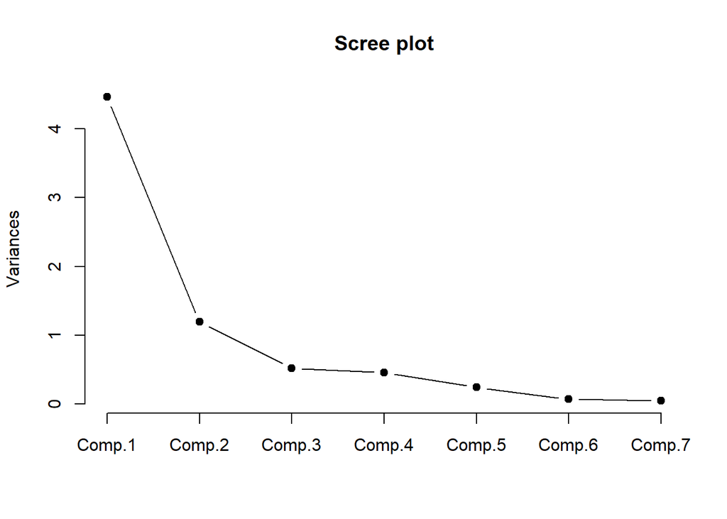

```r
# 스크리 그림
screeplot(hep_pca, type="lines", pch=19, main="Scree plot")
```

- 스크리 그림에서 고윳값이 1보다 큰 주성분은 comp.1과 comp.2 임을 알 수 있다.

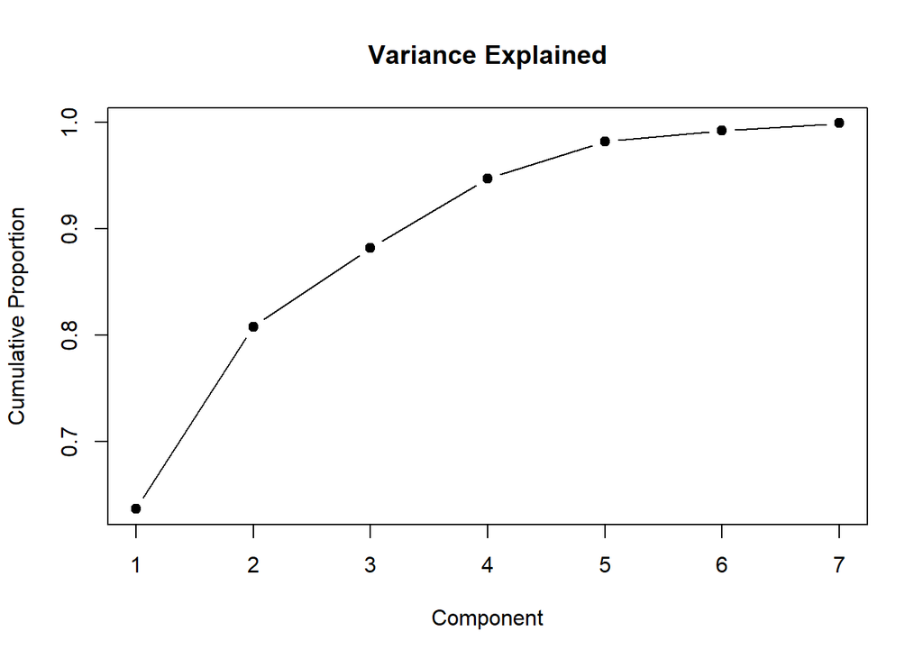

```r
# 누적분산 그림 그리기
hep_var = hep_pca$sdev^2
hep_var_ratio=round(hep_var/sum(hep_var),3)
plot(cumsum(hep_var_ratio), type='b', pch=19, xlab="Component", ylab="Cumulative Proportion")
title("Variance Explained")
```

- 누적분산 그림은 주성분의 표준편차를 제곱하여 분산을 구한 후 그림.

```r
# 주성분계수
hep_pca$loadings[, c(1,2)]
```

```
##             Comp.1      Comp.2
## hurdles  0.4528710  0.15792058
## highjump 0.3771992  0.24807386
## shot     0.3630725 -0.28940743
## run200m  0.4078950 -0.26038545
## longjump 0.4562318  0.05587394
## javelin  0.0754090 -0.84169212
## run800m  0.3749594  0.22448984
```

#### ③ 주성분점수 및 행렬도

```r
hep_pca$scores[, c(1,2,3)]
```

```
##                          Comp.1      Comp.2      Comp.3
## Joyner-Kersee (USA)  4.20643487 -1.26802363 -0.37754097
## John (GDR)           2.94161870 -0.53452561 -0.91592007
## Behmer (GDR)         2.70427114 -0.69275901  0.46864523
## Sablovskaite (URS)   1.37105209 -0.70655862 -0.60754535
## Choubenkova (URS)    1.38704979 -1.78931718  0.15380883
## Schulz (GDR)         1.06537236  0.08104469  0.68843980
## Fleming (AUS)        1.12307639  0.33042906  0.07494589
## Greiner (USA)        0.94221015  0.82345074 -0.82917132
## Lajbnerova (CZE)     0.54118484 -0.14933917 -0.16455206
## Bouraga (URS)        0.77548704  0.53686251 -0.18694589
## Wijnsma (HOL)        0.56773896  1.42507414  0.13900306
## Dimitrova (BUL)      1.21091937  0.36106077  0.08370359
## Scheider (SWI)      -0.01578005 -0.82307249  2.00802405
## Braun (FRG)         -0.00385205 -0.72953750  0.33166887
## Ruotsalainen (FIN)  -0.09261899 -0.77877955  0.96521535
## Yuping (CHN)         0.14005513  0.54831883 -1.08726184
## Hagger (GB)         -0.17465745  1.77914066 -0.59911506
## Brown (USA)         -0.52996001 -0.74195530  0.31947785
## Mulliner (GB)       -1.14869009  0.64788023 -0.74025703
## Hautenauve (BEL)    -1.10808552  1.88531477 -0.01482706
## Kytola (FIN)        -1.47689483  0.94353198  0.65928336
## Geremias (BRA)      -2.05556037  0.09495979 -0.66139188
## Hui-Ing (TAI)       -2.93969248  0.67514662  0.76481968
## Jeong-Mi (KOR)      -3.03136461  0.97939889  0.58296583
## Launa (PNG)         -6.39931438 -2.89774561 -1.05547285
```

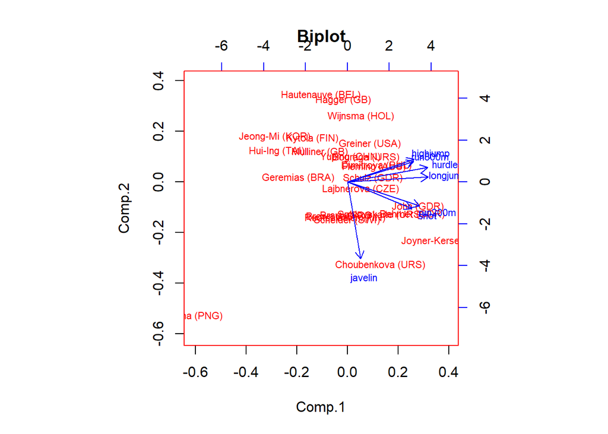

```r
# 행렬도 그리기
biplot(hep_pca, cex=0.7, col=c("Red", "Blue"))
title("Biplot")
```

- 행렬도에서 ’highjump, run800m, hurdles, longjump’가 서로 가꾸운 곳에 위치하며 벡터의 방향도 어느정도 비슷하다.  
  ’run200m, shot’이 가깝게 위치하고, javelin은 다른 변수들과 다른 방향에 위치하고 있다.
- 가까운 거리와 방향일수록 변수들의 상관성이 높아지게 된다.  
  또한 각 개체가 특정 변수에 가깝게 위치할 수록 그 개체는 해당 변수와 관련이 높다고 할 수 있다.

## R을 이용한 주성분분석(2)

### (1) 자료읽기 및 요약통계량

```r
beer = read.csv("./data/beer.csv")
head(beer)
```

```
##   cost size alcohol reputat color aroma taste
## 1   10   15      20      85    40    30    50
## 2  100   70      50      30    75    60    80
## 3   65   30      35      80    80    60    90
## 4    0    0      20      30    80    90   100
## 5   10   25      10     100    50    40    60
## 6   25   35      30      40    45    30    65
```

```r
summary(beer)
```

```
##       cost             size          alcohol         reputat
##  Min.   :  0.00   Min.   : 0.00   Min.   :10.00   Min.   : 30.00
##  1st Qu.: 10.00   1st Qu.:10.00   1st Qu.:15.00   1st Qu.: 30.00
##  Median : 15.00   Median :15.00   Median :20.00   Median : 40.00
##  Mean   : 27.78   Mean   :22.22   Mean   :23.89   Mean   : 55.56
##  3rd Qu.: 25.00   3rd Qu.:30.00   3rd Qu.:30.00   3rd Qu.: 80.00
##  Max.   :100.00   Max.   :70.00   Max.   :50.00   Max.   :100.00
##      color           aroma           taste
##  Min.   :40.00   Min.   :30.00   Min.   : 50.00
##  1st Qu.:50.00   1st Qu.:40.00   1st Qu.: 65.00
##  Median :60.00   Median :60.00   Median : 85.00
##  Mean   :63.89   Mean   :56.11   Mean   : 80.56
##  3rd Qu.:80.00   3rd Qu.:65.00   3rd Qu.: 95.00
##  Max.   :95.00   Max.   :90.00   Max.   :100.00
```

### (2) 상관계수행렬 및 산점도행렬

```r
round(cor(beer),2)
```

```
##          cost  size alcohol reputat color aroma taste
## cost     1.00  0.88    0.88   -0.17  0.32 -0.03  0.05
## size     0.88  1.00    0.82   -0.06  0.01 -0.29 -0.31
## alcohol  0.88  0.82    1.00   -0.36  0.40  0.10  0.06
## reputat -0.17 -0.06   -0.36    1.00 -0.52 -0.52 -0.63
## color    0.32  0.01    0.40   -0.52  1.00  0.82  0.80
## aroma   -0.03 -0.29    0.10   -0.52  0.82  1.00  0.87
## taste    0.05 -0.31    0.06   -0.63  0.80  0.87  1.00
```

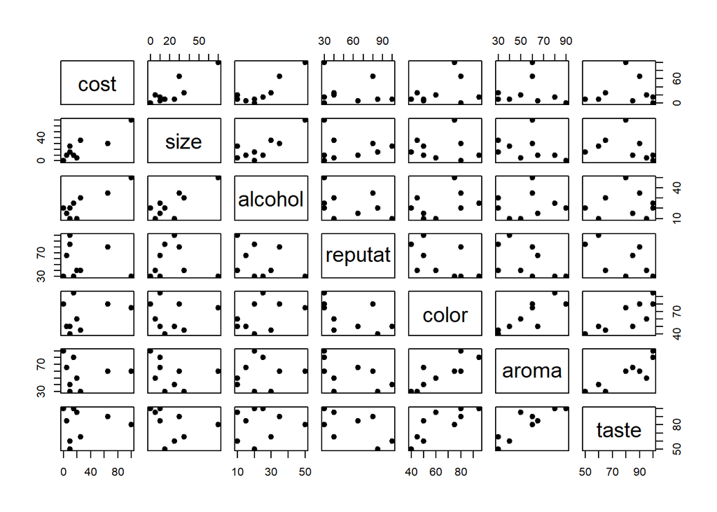

```r
plot(beer, pch=19)
```

- 맥주의 가격(cost), 크기(size), 알코올 함량(alcohol)의 상관관계가 높아 서로 양의 상관관계가 있을 것으로 보인다.  
  또한 색(color), 향기(aroma), 맛(taste)이 서로 상관계수가 높게 나타났다.
- 반면에 평판(reputat)은 다른 변수들과 상관계수가 비교적 높지 않으며, 다른 변수들과 모두 음의 상관계수를 나타냈다.

### (3) 주성분분석 실행

```r
# cof=F : 공분산행렬을 이용하라,
# scores=T : 각 케이스의 주성분점수를 포함하라라
(beer_pca = princomp(beer, cor=F, scores=T))
```

```
## Call:
## princomp(x = beer, cor = F, scores = T)
##
## Standard deviations:
##    Comp.1    Comp.2    Comp.3    Comp.4    Comp.5    Comp.6    Comp.7
## 39.117489 34.783073 17.974805  8.456192  6.479111  4.381410  2.579257
##
##  7  variables and  99 observations.
```

- 주성분의 표준편차(Standard deviations)와 변수수, 케이스수를 보여주고 있다.

### (4) 주성분분석 결과

#### ①결과 요약(summary)

```r
summary(beer_pca)
```

```
## Importance of components:
##                            Comp.1     Comp.2     Comp.3     Comp.4     Comp.5
## Standard deviation     39.1174891 34.7830731 17.9748054 8.45619163 6.47911123
## Proportion of Variance  0.4778119  0.3777904  0.1008889 0.02232876 0.01310829
## Cumulative Proportion   0.4778119  0.8556024  0.9564913 0.97882003 0.99192831
##                            Comp.6      Comp.7
## Standard deviation     4.38141009 2.579257268
## Proportion of Variance 0.00599436 0.002077325
## Cumulative Proportion  0.99792268 1.000000000
```

- 표준편차 (Standard deviation)
- 분산의 비율(Proportion of Variance)
- 누적비율(Cumulative Proportion)

#### ② 스크리 그림 및 주성분 계수

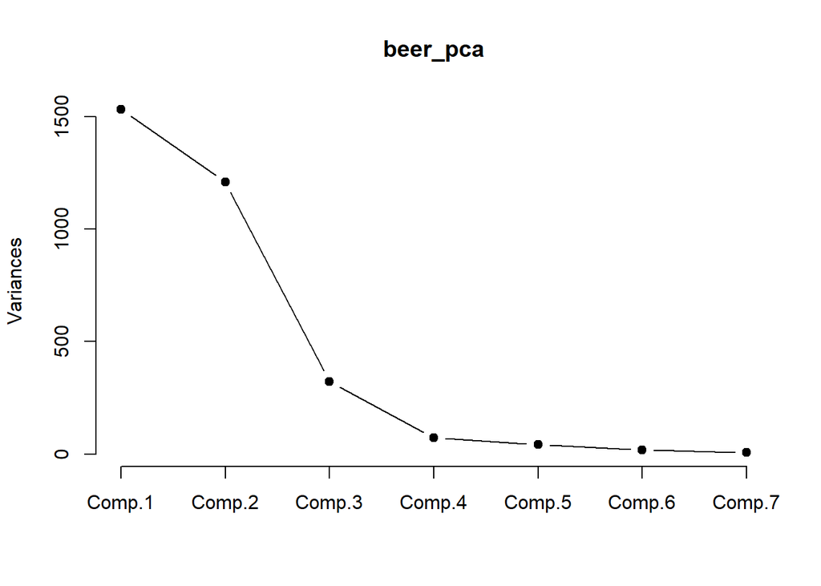

```r
# 스크리 그림
screeplot(beer_pca, type="lines", pch=19)
```

- 스크리 그림에서 유효한 주성분은 3개로 판단

```r
#주성분계수
beer_pca$loadings[, c(1:3)]
```

```
##             Comp.1      Comp.2     Comp.3
## cost     0.7344197  0.31868378  0.1902272
## size     0.3942553  0.34017182 -0.1274959
## alcohol  0.2831873  0.06888179 -0.0370581
## reputat -0.3356901  0.49057105  0.7861697
## color    0.2657171 -0.34379889  0.3862210
## aroma    0.1398211 -0.48510439  0.3693624
## taste    0.1488354 -0.42871339  0.2062207
```

- 주성분계수를 통해 3주성분은
  - $PC_1 = 0.734*cost + 0.394*size + ... + 0.149*taste$
  - $PC_2 = 0.319*cost + 0.340*size + ... - 0.429*taste$
  - $PC_3 = 0.190*cost - 0.127*size + ... + 0.206*taste$